# Deliverable 5: Final Draft

Valentine Hartman

2026-11-14

## Libraries

```r
library("dplyr") #Used for manipulating various instances of the data to make it easier to process
```

```r
library("tidyr") #Used to re-arrange specific variables, making them easier to plot
library("ggplot2") #Used to create proper visual representations of my work, both charts and maps
library("plotly") #Used to make certain visuals and charts with small or hard to view details easier to understand
```

## Summary

> In this project, I took a data set of buildings from the IOLP, a database of properties owned and leased by the American government, and attempted to find patterns in the data regarding each building within it. I explored a handfull of the variables regarding each building, including their geographic location, date of construction, and the rentable and available space of each building in terms of square footage. By the end of my project, I had found a handfull of patterns in the data. There was a noticeable density of buildings near the Eastern side of the country, as well as a handfull of government-owned buildings strung across the Northern and Southern borders. There was also an incredibly high density of both owned and leased government buildings in Texas and California, which even surpassed the amount of government buildings in America’s capital.

## Purpose

> My goal for this project is to find any kind of pattern in the geographic placement of government buildings. I also aim to try and find patterns in the other data regarding these buildings, such as the date of their construction, or the amount of available and rentable square footage within them.

## Data

### Data Dictionary

> The following “data dictionary” serves as an overview of each variable from the data’s original state, and provides the following:
> 1. The variable’s name.
> 2. A brief description of the variable and its contents.
> 3. The data type of the variable (categorical or numerical).
> 4. The specific measurement units of the variable, if it has them.

> **NOTE:** Descriptions of the data can also be found on the website that I pulled the data from.

> [Source of data and overview of the variables within it](https://catalog.data.gov/dataset/inventory-of-owned-and-leased-properties-iolp)

#### “Location.Code”

> This variable contains location codes, the GSA’s method for identifying each property.

> Variable Type: Categorial

> Unit of measurement: None

#### “Real.Property.Asset.Name”

> This variable contains the name of each building It was made with the intent of aiding viewers of the data in locating information on specific properties. A handfull of the values within this variable match their observations’s entry in the “Street.Address” variable.

> Variable type: Categorical

> Unit of measurement: None

#### “Installation.Name”

> This variable primarily consists of N/A values. The few values that it does list are meant to group together buildings that are parts of specific instilations.

> Variable type: Categorical

> Unit of measurement: None

#### “Owned.or.Leased”

> This variable seperates leased and owned buildings. Its entries are all either “OWNED” or “LEASED.” This data will be invaluable for determining the distribution of the two types of buildings across the United States.

> Variable type: Categorical

> Unit of measurement: None

#### “GSA.Region”

> The GSA, the administration that curates the IOLP and locates property for government use, divides the acuisition and management of various buildings among 11 districts, with each one encompassing different states. This variable organizes buildings into districts using a number associated with each district.

> Variable type: Numerical

> Unit of measurement: None

#### “Street.Address”

> This variable contains the street adress of the buildings in the address. Some of the entries in this variable correspond with their observations’s value in the “Real.Property.Asset.Name” variable.

> Variable type: Categorical

> Unit of measurement: None

#### “City”

> This variable contains the name of the city that each property is located in.

> Variable type: Categorical

> Unit of measurement: None

#### “State”

> This variable contains an abbreviation of the state or territory that houses each building.

> Variable type: Categorical

> Unit of measurement: None

#### “Zip.Code”

> This variable contains each building’s zip code.

> Variable type: Numerical

> Unit of measurement: None

#### “Latitude”

> This variable contains the y-value of each building on the global coordinate grid.

> Variable type: Numerical

> Unit of measurement: None

#### “Longitude”

> This variable contains the x-value of each building on the global coordinate grid.

> Variable type: Numerical

> Unit of measurement: None

#### “Building.Rentable.Square.Feet”

> This variable displays the total rentable area of each building in square feet.

> Variable type: Numerical

> Unit of measurement: Square feet

#### “Available.Square.Feet”

> This variable displays the total amount of vacant square footage within a building.

> Variable type: Numerical

> Unit of measurement: Square feet

#### “Construction.Date”

> This variable lists the year that each building was built, in the form of a 4-digit number representing the number of days since January 1st of 1970.

> Variable type: Date (numerical)

> Unit of measurement: None

#### “Congressional.District”

> This variable contains the congressional district each building is located within.

> Variable type: Numerical

> Unit of measurement: None

#### “Congressional.District.Representative.Name”

> This variable contains the name of the representative in charge of the congressional district that each building is located in.

> Variable type: Categorical

> Unit of measurement: None

#### “Building.Status”

> This variable indicates wether or not the building is actively in use.

> Variable type: Categorical

> Unit of measurement: None

#### “Real.Property.Asset.Type”

> This variable displays what kind of asset is housed on each property. All of the entries in the data are listed as buildings, which I later realized meant that all of the properties in my data set were buildings, rather than a variety of property types. I altered the wording of my project to reflect this.

> Variable type: Categorical

> Unit of measurement: None

### N/A values in my data

#### Available.Square.Feet

> One of the most glaring examples of N/A values in my data was the available square footage variable, where 5,721 variables were listed as N/A. These values were left in, as I figured it was completely possible for a government building to not have any vacant space within itself.

#### Construction.Date

> The construction date variable contained about 5,992 N/A observations. I left them in, as my core data goals didn’t nessecarily require the date. Furthermore, the fact that this density of N/A values was exclusively tied to the leased buildings seemed very worthy of note.

### Data Cleaning

> I also used the “Owned.or.Leased” variable to properly sort the buildings into ones that were officially owned by the government and ones that were simply being leased by it via the filter and sort functions. I stored these variables as “IOLP.owned” and “IOLP.leased.” I also renamed IOLPB to “IOLP.all” to make future data more manageable. I removed the Owned.or.Leased variable from both IOLP.owned and IOLP.leased after creating them, as they were already sorted in this state, making that variable pointless in their current states.

> Finally, I used the mutate function and as.Date function to turn the 4-digit format of the construction date into a proper date format. This way, I could also test if there was any pattern in the date the buildings were constructed.

### Code for Data Cleaning

> This code contains the cleaning of my data as mentioned in the previous section.

```r
IOLPB<-read.csv("IOLPBuildings.csv")
IOLPBUS<-IOLPB%>%filter(State!="AS"&State!="GU"&State!="MP"&State!="PR"&State!="VI"&State!="CU")
IOLP.all<-IOLPBUS
IOLP.owned<-(IOLPBUS%>%filter(Owned.or.Leased=="OWNED")%>%select(-Owned.or.Leased))
IOLP.leased<-(IOLPBUS%>%filter(Owned.or.Leased=="LEASED")%>%select(-Owned.or.Leased))
IOLP.all <- IOLP.all %>%
mutate(Construction.Date = as.Date(Construction.Date, origin = "1970-01-01"))
IOLP.owned <- IOLP.owned %>%
mutate(Construction.Date = as.Date(Construction.Date, origin = "1970-01-01"))
IOLP.leased <- IOLP.leased %>%
mutate(Construction.Date = as.Date(Construction.Date, origin = "1970-01-01"))
head(IOLP.all,10)
```

```
##    Location.Code                       Real.Property.Asset.Name
## 1         AK0001            ANCHORAGE HISTORIC FEDERAL BUILDING
## 2         AK0005                     KETCHIKAN FEDERAL BUILDING
## 3         AK0009                           POST OFFICE AND CU H
## 4         AK0013   HURFF A. SAUNDERS FB & ROBERT BOOCHEVER USCH
## 5         AK0029                     FAIRBANKS FEDERAL BUILDING
## 6         AK0031 ANCHORAGE FED. BLDG & JAMES M. FITZGERALD USCH
## 7         AK0032 ANCHORAGE FEDERAL BUILDING US COURTHOUSE ANNEX
## 8         AK0036                      ALCAN RECREATION BUILDING
## 9         AK0037                            ALCAN POLE BUILDING
## 10        AK0038                 POKER CREEK LAND PORT OF ENTRY
##    Installation.Name Owned.or.Leased GSA.Region             Street.Address
## 1  ANCHORAGE FEDERAL           OWNED         10              605 W 4TH AVE
## 2  KETCHIKAN FEDERAL           OWNED         10             648 MISSION ST
## 3                N/A          LEASED         10     2ND ST 112 FEDERAL WAY
```

[output cut: 51 more lines]

```r
head(IOLP.owned,10)
```

```
##    Location.Code                       Real.Property.Asset.Name
## 1         AK0001            ANCHORAGE HISTORIC FEDERAL BUILDING
## 2         AK0005                     KETCHIKAN FEDERAL BUILDING
## 3         AK0013   HURFF A. SAUNDERS FB & ROBERT BOOCHEVER USCH
## 4         AK0029                     FAIRBANKS FEDERAL BUILDING
## 5         AK0031 ANCHORAGE FED. BLDG & JAMES M. FITZGERALD USCH
## 6         AK0032 ANCHORAGE FEDERAL BUILDING US COURTHOUSE ANNEX
## 7         AK0036                      ALCAN RECREATION BUILDING
## 8         AK0037                            ALCAN POLE BUILDING
## 9         AK0038                 POKER CREEK LAND PORT OF ENTRY
## 10        AK0040                               ALCAN LAND LEASE
##    Installation.Name GSA.Region             Street.Address      City State
## 1  ANCHORAGE FEDERAL         10              605 W 4TH AVE ANCHORAGE    AK
## 2  KETCHIKAN FEDERAL         10             648 MISSION ST KETCHIKAN    AK
## 3                N/A         10  709 W 9TH ST FB/USPO/USCH    JUNEAU    AK
```

[output cut: 51 more lines]

```r
head(IOLP.leased,10)
```

```
##    Location.Code       Real.Property.Asset.Name Installation.Name GSA.Region
## 1         AK0009           POST OFFICE AND CU H               N/A         10
## 2         AK3139                 TROUTTE CENTER               N/A         10
## 3         AK3166                 PETERSON TOWER               N/A         10
## 4         AK3177           TUDOR BUSINESS CNTER               N/A         10
## 5         AK3180               MICHAEL BUILDING               N/A         10
## 6         AK3219                 RHINE BUILDING               N/A         10
## 7         AK3227 ELIZABETH PERATROVICH BUILDING               N/A         10
## 8         AK3228                     K & R BLDG               N/A         10
## 9         AK3237           VECO ALASKA BUILDING               N/A         10
## 10        AK3239 ALASKA PACIFIC UNIV.GRACE HALL               N/A         10
##            Street.Address       City State Zip.Code Latitude Longitude
## 1  2ND ST 112 FEDERAL WAY   WRANGELL    AK    99929 56.47395 -132.3881
## 2           329 HARBOR DR      SITKA    AK    99835 57.05028 -135.3336
## 3                510 L ST  ANCHORAGE    AK    99501 61.21715 -149.9043
```

[output cut: 40 more lines]

> Final Dimensions of Base Data Sets: IOLP.all: 7,659 observations, 18 variables IOLP.owned: 1,670 observations, 17 variables IOLP.leased: 5,989 observations, 17 variables

## Exploratory Data Analysis

### Total Concentration of buildings per. state

```r
statesbar.all<-IOLP.all%>%group_by(State)%>%summarise(Property.Density=n())%>%arrange(-Property.Density)%>%mutate(state = State)
IOLP.all.and.Statesbars<-full_join(IOLP.all, statesbar.all, by = "State")
propdist<-(ggplot(IOLP.all.and.Statesbars) +
geom_bar(aes(x = State, fill = Owned.or.Leased))+scale_fill_manual(values = c(
"LEASED" = "blue","OWNED" = "orange"))+coord_flip()+labs(x="State", y="Government Buildings", title="Total Government Building Distribution Among States"))
ggplotly(propdist)
```

[interactive chart not shown]

```r
statesbar.all
```

```
## # A tibble: 51 × 3
##    State Property.Density state
##    <chr>            <int> <chr>
##  1 TX                 703 TX
##  2 CA                 628 CA
##  3 DC                 376 DC
##  4 FL                 367 FL
##  5 VA                 317 VA
##  6 MD                 303 MD
##  7 NY                 297 NY
##  8 PA                 216 PA
##  9 IL                 205 IL
## 10 MI                 201 MI
## # ℹ 41 more rows
```

> This chart is one of the first ones that I made in my exploration of the data, and was designed to help me get a general idea of the locations of government buildings before the creation of proper maps. It was here that I realized that Texas and California had incredibly high concentrations of government buildings, while DC had the highest concentration of owned buildings. Also shown is a simple table of the states organized by their building density.

### Observation of Building Construction Dates

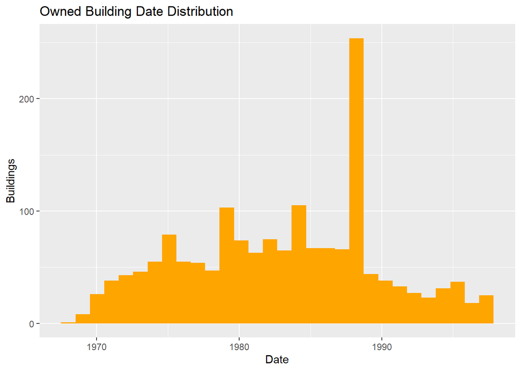

```r
ggplot(IOLP.owned)+geom_histogram(aes(x = Construction.Date,),fill="orange") + labs(x= "Date", y="Buildings",title="Owned Building Date Distribution")
```

> While the date of construction for each of the buildings was not my original point of focus for my project, I later decided to look into them via histogram. However, it is through this examination that I realized that none of the leased buildings in the database have a construction date listed. I also noticed a signifigant spike in the construction date of the buildings within the late 80s, followed by a gradual dip throughout the 1990s.